# Exercise 3.11 - Regular Bike Ridership

Beta-Binomial model pre proporciu cyklistov

Dana Kozáková

2025-10-24

## Úvod

Riešenie cvičenia 3.11 z knihy [Bayes Rules!](https://www.bayesrulesbook.com/chapter-3#exercises-2)

Použitie Beta-Binomial modelu na odhad proporcie študentov, ktorí sú pravidelnými cyklistami.

## Exercise 3.11: Regular Bike Ridership

> A university wants to know what proportion of students are regular bike riders, $\pi$, so that they can install an appropriate number of bike racks. Since the university is in sunny Southern California, staff think that $\pi$ has a mean of 1 in 4 students, and a mode of 5/22.
> 1. Specify and plot a Beta model that reflects the staff’s prior ideas about $\pi$.
> 2. Among 50 surveyed students, 15 are regular bike riders. What is the posterior model for $\pi$?
> 3. What is the mean, mode, and standard deviation of the posterior model?
> 4. Does the posterior model more closely reflect the prior information or the data? Explain your reasoning.

## Zadanie úlohy

### Kontext

**Parameter záujmu:** $\pi$ = proporcia študentov, ktorí sú pravidelnými cyklistami

**Dané informácie o priore:**

- Stredná hodnota: $E(\pi) = \frac{1}{4} = 0.25$
- Modus: $\text{Mode}(\pi) = \frac{5}{22} \approx 0.2273$

**Dáta z prieskumu:**

- Počet opýtaných študentov: $n = 50$
- Počet pravidelných cyklistov: $y = 15$

## Solution

### a. Špecifikácia a vykreslenie apriórneho Beta modelu

#### Výpočet parametrov $\alpha$ a $\beta$ z prioru

Pre Beta($\alpha, \beta$) rozdelenie platí:

$$\begin{align}
E(\pi) &= \frac{\alpha}{\alpha + \beta} \\
\text{Mode}(\pi) &= \frac{\alpha - 1}{\alpha + \beta - 2} \quad
\text{pre } \alpha, \beta > 1
\end{align}$$

Máme dané:

$$\begin{align}
E(\pi) &= 0.25 \\
\text{Mode}(\pi) &= \frac{5}{22} \approx 0.2273
\end{align}$$

**Riešenie sústavy rovníc:**

Z prvej rovnice:
$$\begin{equation}
\frac{\alpha}{\alpha + \beta} = 0.25 \implies \alpha = 0.25(\alpha +
\beta) \implies \alpha = 0.25\alpha + 0.25\beta \implies 0.75\alpha =
0.25\beta \implies \beta = 3\alpha
\end{equation}$$

Z druhej rovnice:
$$\begin{equation}
\frac{\alpha - 1}{\alpha + \beta - 2} = \frac{5}{22}
\end{equation}$$

Dosadíme $\beta = 3\alpha$:
$$\begin{align}
\frac{\alpha - 1}{\alpha + 3\alpha - 2} &= \frac{5}{22} \\
\frac{\alpha - 1}{4\alpha - 2} &= \frac{5}{22} \\
22(\alpha - 1) &= 5(4\alpha - 2) \\
22\alpha - 22 &= 20\alpha - 10 \\
2\alpha &= 12 \\
\alpha &= 6
\end{align}$$

A teda:
$$\begin{equation}
\beta = 3\alpha = 3 \times 6 = 18
\end{equation}$$

**Apriórny model:**
$$\begin{equation}
\pi \sim \text{Beta}(6, 18)
\end{equation}$$

```r
# Výpočet parametrov prioru
alpha_prior <- 6
beta_prior <- 18

# Overenie výpočtov
mean_prior <- alpha_prior / (alpha_prior + beta_prior)
mode_prior <- (alpha_prior - 1) / (alpha_prior + beta_prior - 2)
var_prior <- (alpha_prior * beta_prior) / ((alpha_prior + beta_prior)^2 * (alpha_prior + beta_prior + 1))
sd_prior <- sqrt(var_prior)

cat("Apriórny model: Beta(", alpha_prior, ", ", beta_prior, ")\n", sep = "")
```

```
## Apriórny model: Beta(6, 18)
```

```r
cat("Stredná hodnota:", round(mean_prior, 4), "(požadované: 0.25)\n")
```

```
## Stredná hodnota: 0.25 (požadované: 0.25)
```

```r
cat("Modus:", round(mode_prior, 4), "(požadované:", round(5/22, 4), ")\n")
```

```
## Modus: 0.2273 (požadované: 0.2273 )
```

```r
cat("Smerodajná odchýlka:", round(sd_prior, 4), "\n")
```

```
## Smerodajná odchýlka: 0.0866
```

**Overenie:**
$$\begin{align}
E(\pi) &= \frac{6}{6 + 18} = \frac{6}{24} = 0.25 \quad ✓ \\
\text{Mode}(\pi) &= \frac{6 - 1}{6 + 18 - 2} = \frac{5}{22} \approx
0.2273 \quad ✓
\end{align}$$

#### Graf apriórneho modelu

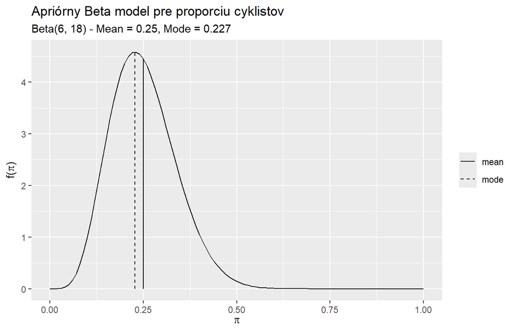

```r
plot_beta(alpha = alpha_prior, beta = beta_prior, mean = TRUE, mode = TRUE) +
  labs(
    title = "Apriórny Beta model pre proporciu cyklistov",
    subtitle = paste0("Beta(", alpha_prior, ", ", beta_prior, ") - Mean = ",
                     round(mean_prior, 3), ", Mode = ", round(mode_prior, 3))
  )
```

**Charakteristiky apriórneho modelu:**

```r
summarize_beta(alpha = alpha_prior, beta = beta_prior)
```

```
##   mean      mode    var         sd
## 1 0.25 0.2272727 0.0075 0.08660254
```

### b. Posteriórny model pre $\pi$

#### Beta-Binomial model

Pre Beta-Binomial model platí:

**Prior:**
$$\begin{equation}
\pi \sim \text{Beta}(\alpha, \beta)
\end{equation}$$

**Dáta:**
$$\begin{equation}
Y | \pi \sim \text{Binomial}(n, \pi)
\end{equation}$$

**Posterior:**
$$\begin{equation}
\pi | Y = y \sim \text{Beta}(\alpha + y, \beta + n - y)
\end{equation}$$

#### Výpočet posterioru

Máme: - Prior: Beta(6, 18) - Dáta: $y = 15$ úspechov z $n = 50$ pokusov

Posterior:
$$\begin{align}
\alpha_{post} &= \alpha + y = 6 + 15 = 21 \\
\beta_{post} &= \beta + n - y = 18 + 50 - 15 = 53
\end{align}$$

**Posteriórny model:**
$$\begin{equation}
\boxed{\pi | y \sim \text{Beta}(21, 53)}
\end{equation}$$

```r
# Dáta
n <- 50
y <- 15

# Posteriórne parametre
alpha_post <- alpha_prior + y
beta_post <- beta_prior + n - y

cat("Posteriórny model: Beta(", alpha_post, ", ", beta_post, ")\n", sep = "")
```

```
## Posteriórny model: Beta(21, 53)
```

### c. Charakteristiky posteriórneho modelu

```r
# Výpočet charakteristík posterioru
mean_post <- alpha_post / (alpha_post + beta_post)
mode_post <- (alpha_post - 1) / (alpha_post + beta_post - 2)
var_post <- (alpha_post * beta_post) / ((alpha_post + beta_post)^2 * (alpha_post + beta_post + 1))
sd_post <- sqrt(var_post)

cat("=== Posteriórny model Beta(", alpha_post, ", ", beta_post, ") ===\n", sep = "")
```

```
## === Posteriórny model Beta(21, 53) ===
```

```r
cat("Stredná hodnota (mean):", round(mean_post, 4), "\n")
```

```
## Stredná hodnota (mean): 0.2838
```

```r
cat("Modus (mode):", round(mode_post, 4), "\n")
```

```
## Modus (mode): 0.2778
```

```r
cat("Rozptyl (variance):", round(var_post, 4), "\n")
```

```
## Rozptyl (variance): 0.0027
```

```r
cat("Smerodajná odchýlka (SD):", round(sd_post, 4), "\n")
```

```
## Smerodajná odchýlka (SD): 0.0521
```

#### Použitie funkcie z bayesrules

```r
summarize_beta(alpha = alpha_post, beta = beta_post)
```

```
##        mean      mode         var         sd
## 1 0.2837838 0.2777778 0.002710007 0.05205773
```

### d. Porovnanie prioru, dát a posterioru

#### Porovnávacia tabuľka

```r
# Proporcia z dát
data_proportion <- y / n

comparison <- data.frame(
  Model = c("Prior", "Dáta", "Posterior"),
  Proporcia = c(mean_prior, data_proportion, mean_post),
  SD = c(sd_prior, NA, sd_post),
  Parametre = c(
    paste0("Beta(", alpha_prior, ", ", beta_prior, ")"),
    paste0(y, " z ", n),
    paste0("Beta(", alpha_post, ", ", beta_post, ")")
  )
)

comparison <- comparison %>%
  mutate(Proporcia = round(Proporcia, 4),
         SD = round(SD, 4))

knitr::kable(comparison, caption = "Porovnanie prioru, dát a posterioru")
```

Porovnanie prioru, dát a posterioru

| Model | Proporcia | SD | Parametre |
| --- | --- | --- | --- |
| Prior | 0.2500 | 0.0866 | Beta(6, 18) |
| Dáta | 0.3000 | NA | 15 z 50 |
| Posterior | 0.2838 | 0.0521 | Beta(21, 53) |

#### Vizualizácia prioru, likelihood a posterioru

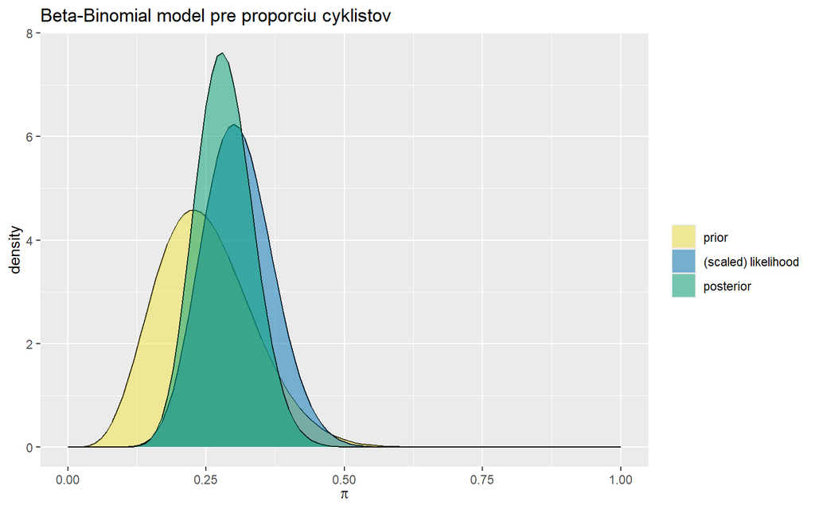

```r
plot_beta_binomial(alpha = alpha_prior, beta = beta_prior, y = y, n = n) +
  labs(title = "Beta-Binomial model pre proporciu cyklistov")
```

#### Analýza: Čo dominuje v posteriore - prior alebo dáta?

**1. Porovnanie proporcií:**

```r
cat("Prior mean:     ", round(mean_prior, 4), " (25.0%)\n")
```

```
## Prior mean:      0.25  (25.0%)
```

```r
cat("Dáta proportion:", round(data_proportion, 4), " (", round(data_proportion*100, 1), "%)\n", sep = "")
```

```
## Dáta proportion:0.3 (30%)
```

```r
cat("Posterior mean: ", round(mean_post, 4), " (", round(mean_post*100, 1), "%)\n\n", sep = "")
```

```
## Posterior mean: 0.2838 (28.4%)
```

```r
cat("Vzdialenosť posterioru od prioru:     ", round(abs(mean_post - mean_prior), 4), "\n")
```

```
## Vzdialenosť posterioru od prioru:      0.0338
```

```r
cat("Vzdialenosť posterioru od dátovej prop.:", round(abs(mean_post - data_proportion), 4), "\n")
```

```
## Vzdialenosť posterioru od dátovej prop.: 0.0162
```

**2. Váhy prioru a dát:**

Posteriórnu strednú hodnotu môžeme vyjadriť ako váženú priemer prioru a dát:

Zjednodušene:
$$\begin{equation}
E(\pi|y) \approx w_{prior} \cdot E(\pi) + w_{data} \cdot \frac{y}{n}
\end{equation}$$

kde váhy sú určené “silou” prioru ($\alpha + \beta$) a počtom dát ($n$).

```r
# Sila prioru a dát
prior_strength <- alpha_prior + beta_prior  # 24
data_strength <- n                          # 50

# Váhy
weight_prior <- prior_strength / (prior_strength + data_strength)
weight_data <- data_strength / (prior_strength + data_strength)

cat("Sila prioru (α + β):", prior_strength, "\n")
```

```
## Sila prioru (α + β): 24
```

```r
cat("Sila dát (n):       ", data_strength, "\n\n")
```

```
## Sila dát (n):        50
```

```r
cat("Váha prioru:        ", round(weight_prior, 4), " (", round(weight_prior*100, 1), "%)\n", sep = "")
```

```
## Váha prioru:        0.3243 (32.4%)
```

```r
cat("Váha dát:           ", round(weight_data, 4), " (", round(weight_data*100, 1), "%)\n\n", sep = "")
```

```
## Váha dát:           0.6757 (67.6%)
```

```r
# Overenie
weighted_mean <- weight_prior * mean_prior + weight_data * data_proportion
cat("Vážený priemer:     ", round(weighted_mean, 4), "\n")
```

```
## Vážený priemer:      0.2838
```

```r
cat("Skutočný posterior: ", round(mean_post, 4), "\n")
```

```
## Skutočný posterior:  0.2838
```

**3. Zmena neistoty:**

```r
cat("Smerodajná odchýlka prioru:    ", round(sd_prior, 4), "\n")
```

```
## Smerodajná odchýlka prioru:     0.0866
```

```r
cat("Smerodajná odchýlka posterioru:", round(sd_post, 4), "\n")
```

```
## Smerodajná odchýlka posterioru: 0.0521
```

```r
cat("Zníženie SD:                    ", round(sd_prior - sd_post, 4),
    " (", round((sd_prior - sd_post)/sd_prior * 100, 1), "%)\n", sep = "")
```

```
## Zníženie SD:                    0.0345 (39.9%)
```

#### Záver k časti d)

**Posterior je bližšie k dátam ako k prioru.**

**Dôvody:**

1. **Dáta majú väčšiu váhu:**
   - Sila dát: $n = 50$
   - Sila prioru: $\alpha + \beta = 24$
   - Dáta majú približne dvojnásobnú váhu (~68% vs ~32%)
2. **Porovnanie proporcií:**
   - Prior mean: 0.25 (25%)
   - Dáta: 15/50 = 0.30 (30%)
   - Posterior mean: 0.284 (28.4%)
   - Posterior je bližšie k 30% (dáta) ako k 25% (prior)
3. **Vzdialenosti:**
   - Vzdialenosť posterior od prioru: 0.0338
   - Vzdialenosť posterior od dát: 0.0162
   - Posterior je približne 2-krát bližšie k dátam
4. **Neistota sa výrazne znížila:**
   - SD prioru: 0.0866 → SD posterioru: 0.0521
   - Zníženie o 39.9%
   - Máme oveľa väčšiu istotu po videní dát

## Samostatný graf posterioru

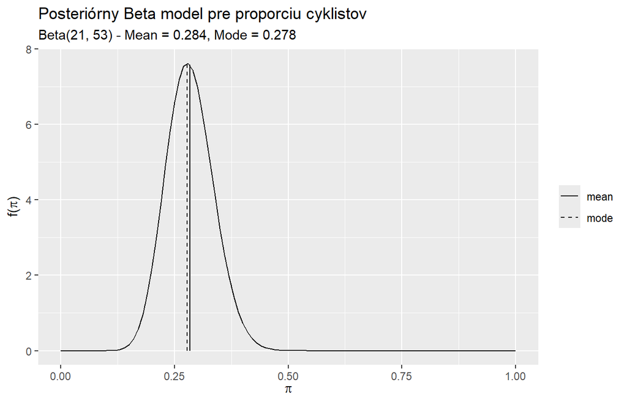

```r
plot_beta(alpha = alpha_post, beta = beta_post, mean = TRUE, mode = TRUE) +
  labs(
    title = "Posteriórny Beta model pre proporciu cyklistov",
    subtitle = paste0("Beta(", alpha_post, ", ", beta_post, ") - Mean = ",
                     round(mean_post, 3), ", Mode = ", round(mode_post, 3))
  )
```

## Zhrnutie

### Evolúcia modelu

| Charakteristika | Prior Beta(6,18) | Dáta | Posterior Beta(21,53) |
| --- | --- | --- | --- |
| Stredná hodnota | 0.25 (25%) | 0.30 (30%) | 0.284 (28.4%) |
| Modus | 0.227 (22.7%) | - | 0.278 (27.8%) |
| Smer. odchýlka | 0.086 | - | 0.052 |
| Sila | 24 | 50 | 74 |

### Kľúčové zistenia

1. **Prior:** Personál univerzity si myslel, že približne 25% študentov pravidelne jazdí na bicykli
2. **Dáta:** V prieskume 50 študentov bolo 15 cyklistov (30%)
3. **Posterior:** Po aktualizácii priorom dátami máme posterior s mean 28.4%
   - Je to kompromis medzi priorom (25%) a dátami (30%)
   - Bližšie k dátam, pretože dáta mali väčšiu váhu
4. **Neistota:** SD klesla z 8.6% na 5.2% - máme väčšiu istotu
5. **Praktický záver:** Univerzita by mala plánovať stojany pre približne **28% študentov**, s rozumnou neistotou ±10% (dva štandardné odchýlky)

## Poznámky k Beta-Binomial modelu

### Interpretácia parametrov

**Posterior Beta(21, 53):**

- Kombinuje prior s novými dátami
- 21 = 6 (prior) + 15 (noví cyklisti)
- 53 = 18 (prior) + 35 (noví necyklisti)
- Celková “sila”: 74 pozorovaní

### Bayesovská aktualizácia

$$\begin{equation}
\text{Posterior} = \frac{\text{Prior} \times
\text{Likelihood}}{\text{Normalizačná konstanta}}
\end{equation}$$

V našom prípade:
$$\begin{equation}
\text{Beta}(21, 53) = \text{Beta}(6, 18) \times \text{Binomial}(15 | 50,
\pi)
\end{equation}$$

Posterior je **kompromis** medzi našim počiatočným presvedčením (prior) a pozorovanými dátami!